# Indonesian Aquaculture Data Visualization

### Purpose

As part of our work towards Activity 3, we are examining the spatial patterns and trends in the Indonesian aquaculture statistics. We have prepared several visuals to give our colleagues an idea of what types of figures could be used in the technical whitepaper. Based on previous discussions, we have tried to draw attention to four provinces of interest: Banten, Jawa Barat, Jawa Timur, and Papua Barat. General thoughts and feedback are welcome. In particular, we hope to gauge how well these figures could be used to support case studies that are relevant to the grander themes and management issues of Indonesian aquaculture.

For example, some management discussions that these visuals could potentially complement include:

- proper siting and spatial management of extensive brackish pond aquaculture
- the regional intensification of brackish pond aquaculture and associated environmental concerns
- managing the development of low area, high intensity marine aquaculture production

### Visuals

*Note: Provinces in gray either represent missing or suspect values. For example, Jawa Tengah was calculated to have an intensity above 1000 tons per hectare for brackish pond aquaculture in 2015 (two orders of magnitude higher than the next highest province).*

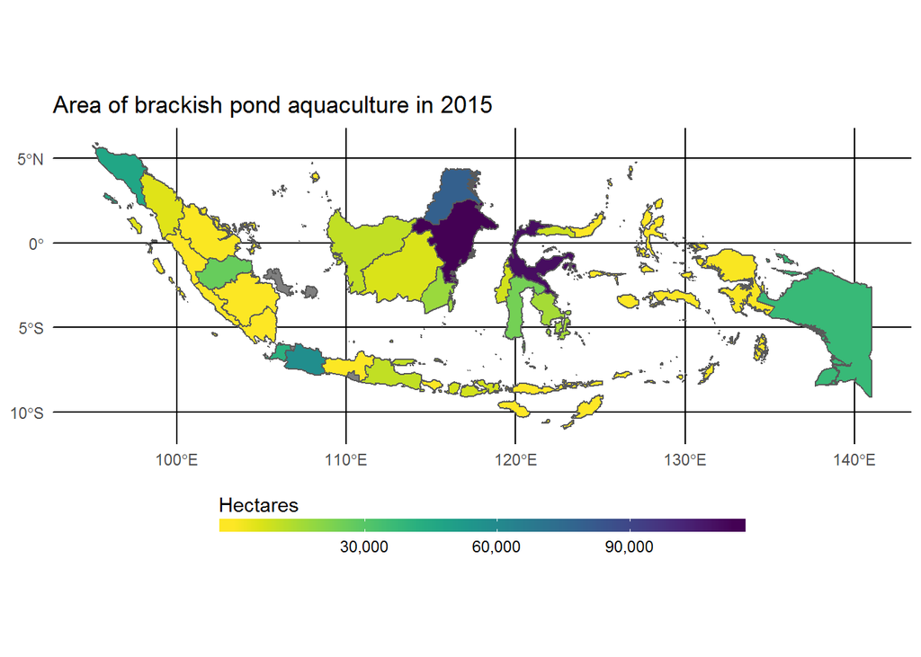

**Figure 1.** The extent of brackish pond aquaculture (hectares) for each province in 2015. Both Banten and Jawa Barat have relatively high amounts of area under production, with the maximum national values occurring in Kalimantan Timur and Sulawesi Tengah.

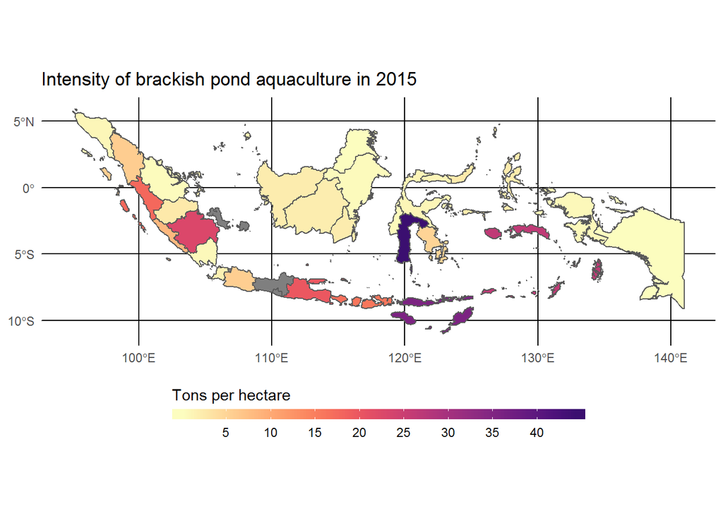

**Figure 2.** Provincial intensity of brackish pond aquaculture (tons/hectare) for 2015. Jawa Timur is highlighted as having more intensive production than Banten or Jawa Barat.

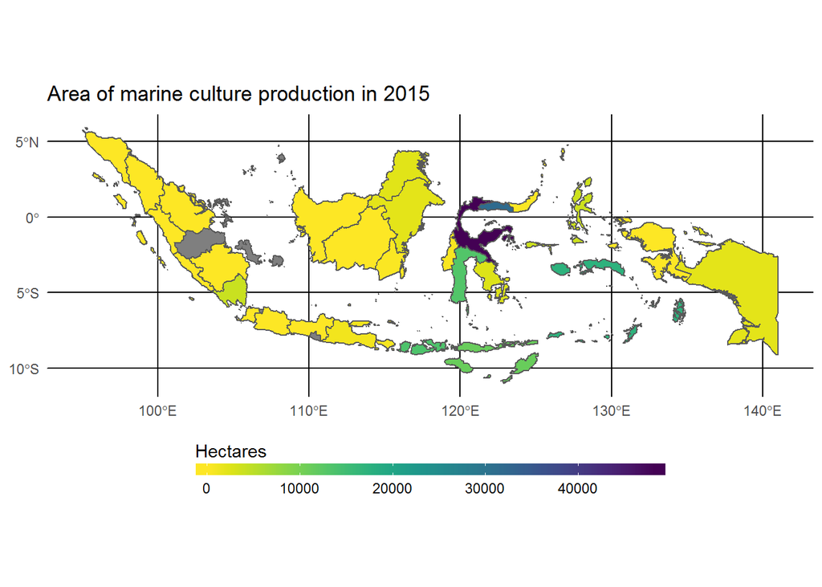

**Figure 3.** The area (hectares) dedicated to marine culture production (believed to be seaweed) in 2015 for each province. Compared to brackish pond aquaculture, marine culture is also quite extensive in Sulawesi Tengah but takes up less than half the total area throughout Indonesia.

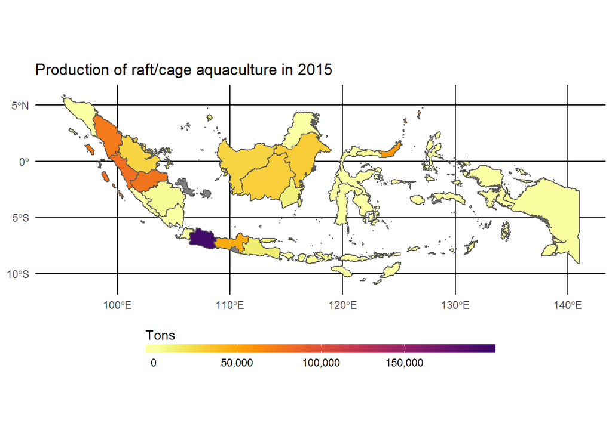

#### *Notes*:

During our data exploration, we encountered a few surprising results. For example, the below figure displays the area used in brackish pond aquaculture for three provinces from 2005 to 2015. All three time series demonstrate either a sharp increase or decrease in 2012. Is it possible that there is a historical explanation for this (e.g. disease outbreak)? Else, it could potentially indicate a data reporting error.

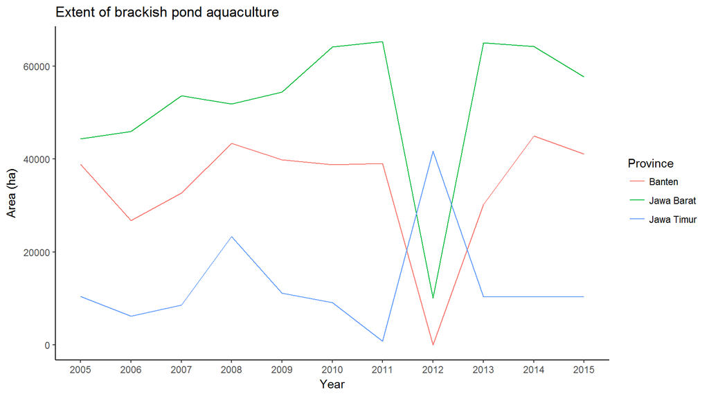